# The market for pharmaceuticals · Health Economics

[interactive chart not shown]

← → 翻页· · ·

**GLOH 2260** · Introduction to Health Economics

Session 11 · 01 / 23

INTRODUCTION TO HEALTH ECONOMICS · FALL 2026

# The market for pharmaceuticals

Innovation, market power and the price of medicines

WU ZENG, MD, PHD · GEORGETOWN UNIVERSITY

THE MARKET FOR PHARMACEUTICALS · FALL 2026

1

**GLOH 2260** · Introduction to Health Economics

Session 11 · 02 / 23

THE AGENDA

## Outline of the session

**Health**How medicines contribute to health and how patients choose among them.

**Prices**How firms set prices, and how insurance changes what patients pay.

**Innovation**How research, patents and regulation affect new drug development.

**Cost control**How generic competition and public policy limit spending.

THE MARKET FOR PHARMACEUTICALS · FALL 2026

2

**GLOH 2260** · Introduction to Health Economics

Session 11 · 03 / 23

WHY THIS MARKET MATTERS

## Medicines can preserve health. Their markets attract scrutiny.

Drug therapies complement nutrition, sanitation and medical care, while pharmaceutical firms rank among the largest and most profitable businesses in the United States.

A product can have major health benefits.

Patents can limit competition.

Regulation shapes both research and access.

THE MARKET FOR PHARMACEUTICALS · FALL 2026

3

**GLOH 2260** · Introduction to Health Economics

Session 11 · 04 / 23

INDUSTRY STRUCTURE

## Drug development is a shared enterprise

**Public research**Government and philanthropy support basic science and knowledge creation.

**Academic research**Universities contribute discoveries, expertise and early-stage research.

**Private development**Firms bring candidates through testing, approval, production and commercialization.

The US has relied heavily on private initiative and market mechanisms to direct commercial R&D.

THE MARKET FOR PHARMACEUTICALS · FALL 2026

4

**GLOH 2260** · Introduction to Health Economics

Session 11 · 05 / 23

PHARMACEUTICAL MARKETS · 1980–2019

## Domestic and global drug markets expanded over four decades

THE MARKET FOR PHARMACEUTICALS · FALL 2026

5

**GLOH 2260** · Introduction to Health Economics

Session 11 · 06 / 23

GLOBAL PHARMA · FY2025

## The ten largest drug developers

**01 Eli Lilly**$65.18bn

**06 AstraZeneca**$58.74bn

**02 Merck & Co.**$65.01bn

**07 Roche**$57.40bn

**03 Pfizer**$62.58bn

**08 Novartis**$56.67bn

**04 AbbVie**$61.16bn

**09 Sanofi**$52.73bn

**05 Johnson & Johnson**$60.40bn

**10 Bristol Myers Squibb**$48.20bn

FY2025 pharmaceutical revenue; non-pharma divisions excluded. [Source: Pharma 50](https://www.drugdiscoverytrends.com/pharma-50-2026-the-top-spot-in-pharma-rarely-lasts-lilly-is-betting-it-can-change-that/).

THE MARKET FOR PHARMACEUTICALS · FALL 2026

6

**GLOH 2260** · Introduction to Health Economics

Session 11 · 07 / 23

OECD · PER-CAPITA SPENDING · PPP-ADJUSTED USD

## US prescription drug spending leads this country group

Public and compulsory coverage account for most US spending, with additional out-of-pocket costs.

[figure not shown]

Approximate values digitized from the supplied OECD graphic. 2022 or 2023; Australia and Japan: 2021. Figures use purchasing power parity. Source: OECD.

Country codes: US United States · DE Germany · CA Canada · JP Japan · KR Korea · ES Spain · AU Australia · NO Norway · GB United Kingdom · MX Mexico

THE MARKET FOR PHARMACEUTICALS · FALL 2026

7

**GLOH 2260** · Introduction to Health Economics

Session 11 · 08 / 23

RESEARCH & DEVELOPMENT

## The role of research and development

**$500bn+**Largest firms’ cumulative R&D spending since 2000.

**$51.2bn**R&D spending in 2014 by the cited group of firms.

**17.9%**Share of combined sales spent on R&D in 2014.

About 75% of global pharmaceutical R&D spending was based in the United States. New products can generate profits, while returns often decline as a product ages.

Historical figures as reported in course materials.

THE MARKET FOR PHARMACEUTICALS · FALL 2026

8

**GLOH 2260** · Introduction to Health Economics

Session 11 · 09 / 23

REGULATION

## FDA and Drug Development

01

Imposes requirements on product testing, safety, effectiveness, and marketing of pharmaceutical products.

02

Monitors for proper manufacturing and labeling standards.

03

Also responsible for food, medical devices, and cosmetics products.

04

FDA approval does not mean a product is harmless.

THE MARKET FOR PHARMACEUTICALS · FALL 2026

9

**GLOH 2260** · Introduction to Health Economics

Session 11 · 10 / 23

REGULATION

## New drug application approval

**Safety and effectiveness**Does the proposed use meet standards for safety and effectiveness?

**Labelling**Does product labeling communicate appropriate directions and warnings?

**Manufacturing**Can manufacturing preserve identity, strength, quality and purity?

**Scope**FDA also regulates food, medical devices and cosmetics.

FDA approval does not mean a product is harmless.

THE MARKET FOR PHARMACEUTICALS · FALL 2026

10

**GLOH 2260** · Introduction to Health Economics

Session 11 · 11 / 23

RESEARCH & DEVELOPMENT

## Drug development moves through long, distinct stages

### Basic science research

2–5 years

Discover and investigate potential targets.

### Preclinical testing

1–2 years

Test candidates before studies in people.

### Clinical trials

Study safety and effectiveness in people.

### FDA review

6 mo.–2 years

Review evidence, labeling and manufacturing.

### Approved drug

May be marketed for its approved use.

**PHASE 1 · 1.6 YEARS**Testing in healthy subjects.

**PHASE 2 · 2.9 YEARS**Testing in individuals with the disease.

**PHASE 3 · 3.8 YEARS**Larger-scale testing in individuals with the disease.

Stage durations are reproduced from the supplied course figure and vary by product.

THE MARKET FOR PHARMACEUTICALS · FALL 2026

11

**GLOH 2260** · Introduction to Health Economics

Session 11 · 12 / 23

RESEARCH & DEVELOPMENT

## Drug development stages

[video not shown]

THE MARKET FOR PHARMACEUTICALS · FALL 2026

12

**GLOH 2260** · Introduction to Health Economics

Session 11 · 13 / 23

POLICY TOWARD INNOVATION

## Exclusivity through patent can support research, and restrict competition

**United States**The 1984 Hatch–Waxman Act restored some patent time lost during FDA review and created an abbreviated route for generic applications.

**International rules**WTO members provide at least 20 years of patent protection from filing.

The policy bargain is between expected returns that may encourage innovation and market power that can raise prices.

THE MARKET FOR PHARMACEUTICALS · FALL 2026

13

**GLOH 2260** · Introduction to Health Economics

Session 11 · 14 / 23

PATENTS & MARKET POWER

## A monopolist limits output to sustain a higher price

- Patents of drugs distort drug prices, limit treatment options for individuals who do not have the means to pay, and cause American consumers to pay too much for their prescription medicines
- The awarding of a patent provides the innovator with monopoly power – to limit availability and set prices above the marginal cost of production
- The profit-maximizing output occurs where MC equals MR. The monopolist then charges the highest price the market will bear, which is given by the demand curve. If price exceeds average cost a profit will be earned

THE MARKET FOR PHARMACEUTICALS · FALL 2026

14

**GLOH 2260** · Introduction to Health Economics

Session 11 · 15 / 23

INSURANCE & PRICE SETTING

## Insurance shifts demand and can raise the monopoly price

- Insurance copayment provisions invite firms with market power to raise their price according to the inverse of the copay
- Insurance shifts demand from D1 to D2 (increases demand)
  - User coinsurance rate (c) determines the magnitude of the shift
  - 100 percent insurance (c = 0) implies the demand curve is vertical
- The 50 percent copay results in the monopolist doubling their prices
  - Price changes from P1 to P2
  - Monopolist could adjust the resulting price-quantity point on the new demand curve by moving from initial quantity only if profits increase

Stylized source model. A higher price is possible under its assumptions; the result is not universal.

THE MARKET FOR PHARMACEUTICALS · FALL 2026

15

**GLOH 2260** · Introduction to Health Economics

Session 11 · 16 / 23

ADVERTISING & PROMOTION

## 2010 spending on promotion reached nearly half of R&D

**$27bn**Marketing and promotion in 2010.

**$56bn**Research and development in 2010.

**70%**Of promotion spending went to free samples and physician promotion, according to course materials.

Historical estimates cited in the source prompt.

THE MARKET FOR PHARMACEUTICALS · FALL 2026

16

**GLOH 2260** · Introduction to Health Economics

Session 11 · 17 / 23

THE PROMOTION DEBATE

## Advertising and Promotion consequences and opinions

- Wholesale price of new drugs three to six times higher than cost of production
- Profits are funneled into advertising and promotion (directed at providers)
- Though most promotion targets physicians, advertising targeting end consumers has grown significantly
- Direct to-consumer advertising (DTCA) rose from $791 million in 1996 to $6.1 billion in 2019
- Critics fear that this promotion motivates without educating consumers
- However, most physicians believe that direct to-consumer advertising informs and educates patients, and the majority of patients believe it increases awareness for new drugs and improves communication with physicians (Moser, 2003)
- Direct to-consumer advertising has no effect on price (Rubin, 2003) but can drastically increase sales (Jenkins, 2000)

THE MARKET FOR PHARMACEUTICALS · FALL 2026

17

**GLOH 2260** · Introduction to Health Economics

Session 11 · 18 / 23

PRICING

## Other factors affecting drug prices

[video not shown]

THE MARKET FOR PHARMACEUTICALS · FALL 2026

18

**GLOH 2260** · Introduction to Health Economics

Session 11 · 19 / 23

PRICE CONTROL POLICIES

## Common pricing control policies

**Set prices**Negotiate ceilings or use cost-plus formulas.

**Benchmark**Use external reference pricing, as in the cited Germany example.

**Shape competition**Promote generic medicines and regulate supply-chain mark-ups.

**Change incentives**Adjust taxes on pharmaceutical products.

**Assess value**Use health technology assessment to inform coverage and price decisions.

Examples in the source material include UK mark-up regulation and Canadian negotiated prices.

THE MARKET FOR PHARMACEUTICALS · FALL 2026

19

**GLOH 2260** · Introduction to Health Economics

Session 11 · 20 / 23

INTERNATIONAL PRICE COMPARISON · 2005

## Retail pharmaceutical prices varied across OECD countries

| Country | Pharma price level | GDP per capita (2005) | GDP per capita level |
| --- | --- | --- | --- |
| Canada | 134 | $36,213 | 105 |
| France | 91 | $30,461 | 88 |
| Germany | 127 | $32,184 | 93 |
| Japan | 118 | $30,442 | 88 |
| Switzerland | 185 | $39,153 | 113 |
| United Kingdom | 92 | $34,623 | 100 |
| United States | 130 | $44,308 | 128 |
| OECD average | 100 | $34,520 | 100 |

Source printed on original figure: OECD Health Policy Studies (2008). Price and GDP levels are indexed to OECD average = 100.

THE MARKET FOR PHARMACEUTICALS · FALL 2026

20

**GLOH 2260** · Introduction to Health Economics

Session 11 · 21 / 23

COUNTRY-SPECIFIC DRUG PRICES · 2015

## Monthly prices differed sharply for selected top-selling drugs

| Drug & regimen | US, non-discounted | US, estimated discounted | Canada | France | Germany |
| --- | --- | --- | --- | --- | --- |
| Adalimumab (Humira), 40 mg biweekly | $3,430.82 | $2,504.50 | $1,164.32 | $981.79 | $1,749.26 |
| Fluticasone/salmeterol (Advair), 250/50 μg daily | $309.60 | $154.80 | $74.12 | $34.52 | $37.71 |
| Insulin glargine (Lantus), 50 units daily | $372.75 | $186.38 | $67.00 | $46.60 | $60.90 |
| Rosuvastatin (Crestor), 10 mg daily | $216.00 | $86.40 | $32.10 | $19.80 | $40.50 |
| Sitagliptin (Januvia), 100 mg daily | $330.60 | $168.61 | $68.10 | $35.40 | $39.00 |
| Sofosbuvir (Sovaldi), 400 mg daily | $30,000.00 | $17,700.00 | $14,943.30 | $16,088.40 | $17,093.70 |
| Trastuzumab (Herceptin), 450 mg every 3 weeks | $5,593.47 | $4,754.45 | — | $2,527.97 | $3,185.87 |

Source figure reports monthly US-dollar prices for 2015. “—” indicates no Canada value shown in the supplied table.

THE MARKET FOR PHARMACEUTICALS · FALL 2026

21

**GLOH 2260** · Introduction to Health Economics

Session 11 · 22 / 23

DISCUSSION

## Which trade-off should policy prioritize?

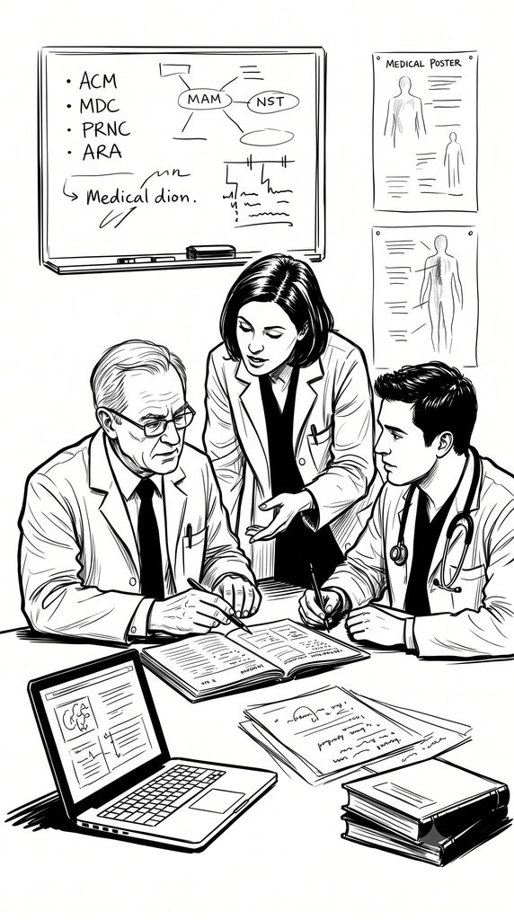

How should a health system reward useful innovation while keeping effective medicines affordable?

Consider patents, insurance, generic entry, promotion and price regulation in your answer.

THE MARKET FOR PHARMACEUTICALS · FALL 2026

22

**GLOH 2260** · Introduction to Health Economics

Session 11 · 23 / 23

SESSION 11 · TAKEAWAY

## The challenge is to reward innovation and protect access.

Patents, insurance, promotion and pricing policy all shape that balance.

WU ZENG · GEORGETOWN UNIVERSITY

THE MARKET FOR PHARMACEUTICALS · FALL 2026

23